# Predicting Board Game Rating - Tidy Tuesday Week 4 2022

# Aim

This project will attempt to predict board game rating from the game category, using the [Tidy Tuesday week 4 data on board games.](https://github.com/rfordatascience/tidytuesday/blob/master/data/2022/2022-01-25/readme.md)

# Data Exploration

Lets take a look at the distribution of the ratings in our dataset:

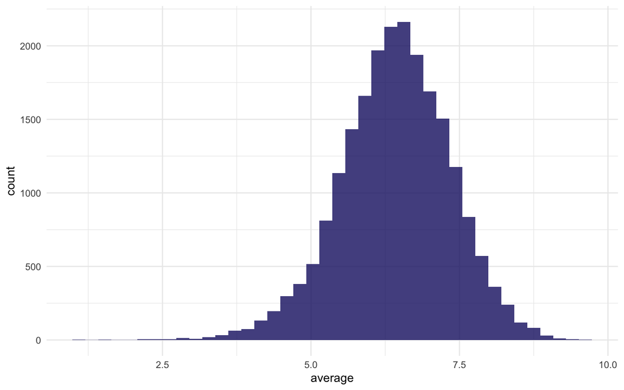

```r
boardgame %>% ggplot(aes(average))+
  geom_histogram(fill="midnightblue", alpha=.8, bins=40)
```

It would also be interesting to look at the most common board game category:

```r
tidy_board <-
  boardgame %>%
  unnest_tokens(word,boardgamecategory)

tidy_board %>%
  count(word,sort = TRUE) %>% filter(word != "game")
```

```
## # A tibble: 112 × 2
##    word          n
##    <chr>     <int>
##  1 card       6402
##  2 wargame    3820
##  3 fantasy    2681
##  4 war        1996
##  5 party      1968
##  6 dice       1847
##  7 fiction    1666
##  8 science    1666
##  9 fighting   1658
## 10 childrens  1635
## # … with 102 more rows
```

It seems that card, war, and fantasy games are well represented. We can further explore the categories by looking at the mean rating by category:

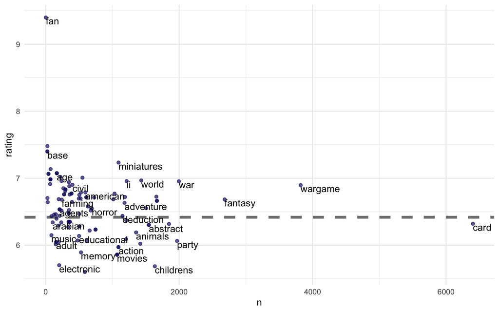

```r
tidy_board %>%
  group_by(word) %>%
  filter(word != "game") %>%
  summarise(
    n = n(),
    rating = mean(average)
  ) %>%
  ggplot(aes(n, rating)) +
  geom_hline(
    yintercept = mean(boardgame$average), lty = 2,
    color = "gray50", size = 1.5
  ) +
  geom_jitter(color = "midnightblue", alpha = 0.7) +
  geom_text(aes(label = word),
            check_overlap = TRUE,
            vjust = "top", hjust = "left"
  )
```

# Building the Models

Lets do some feature engineering for the boardgamecategory variable. The tidymodels framework allows for some flexibility in terms of feature engineering, in this case we need to incorporate a custom feature engineering function to accommodate the structure of the variable.Lets start by creating the splits:

```r
set.seed(123)
board_split <- initial_split(boardgame, strata = average)
board_train <- training(board_split)
board_test <- testing(board_split)

set.seed(234)
board_folds <- vfold_cv(board_train, strata = average)
board_folds
```

```
## #  10-fold cross-validation using stratification
## # A tibble: 10 × 2
##    splits               id
##    <list>               <chr>
##  1 <split [14597/1624]> Fold01
##  2 <split [14597/1624]> Fold02
##  3 <split [14598/1623]> Fold03
##  4 <split [14599/1622]> Fold04
##  5 <split [14599/1622]> Fold05
##  6 <split [14599/1622]> Fold06
##  7 <split [14599/1622]> Fold07
##  8 <split [14599/1622]> Fold08
##  9 <split [14601/1620]> Fold09
## 10 <split [14601/1620]> Fold10
```

Now that we have the respective splits, lets crate our custom feature engineering function, along with the recipe for our workflow:

```r
clean_category <- function(x) {
  x %>%
    str_split(", ") %>%
    map(str_remove_all, "[:punct:]") %>%
    map(str_squish) %>%
    map(str_to_lower) %>%
    map(str_replace_all, " ", "_")
}

board_rec <-
  recipe(average ~ boardgamecategory, data = boardgame) %>%
  step_tokenize(boardgamecategory, custom_token = clean_category) %>%
  step_tokenfilter(boardgamecategory, max_tokens = 50) %>%
  step_tfidf(boardgamecategory)

# Check that the steps worked as envisioned:
prep(board_rec) %>% bake(new_data=NULL) %>% str()
```

```
## tibble [21,631 × 51] (S3: tbl_df/tbl/data.frame)
##  $ average                                       : num [1:21631] 7.59 7.42 7.14 7.74 7.61 7.41 7.6 8.42 8.11 7.93 ...
##  $ tfidf_boardgamecategory_abstract_strategy     : num [1:21631] 0 0 0 0 0 0 0 0 0 0 ...
##  $ tfidf_boardgamecategory_action_dexterity      : num [1:21631] 0 0 0 0 0 0 0 0 0 0 ...
##  $ tfidf_boardgamecategory_adventure             : num [1:21631] 0 0 0 0 0 0 0 0 0 0 ...
##  $ tfidf_boardgamecategory_ancient               : num [1:21631] 0 0 0 0.685 0 ...
##  $ tfidf_boardgamecategory_animals               : num [1:21631] 0 0 0 0 0 ...
##  $ tfidf_boardgamecategory_bluffing              : num [1:21631] 0 0 0 0 0 0 0 0 0 0 ...
##  $ tfidf_boardgamecategory_card_game             : num [1:21631] 0 0 0 0.295 0.738 ...
##  $ tfidf_boardgamecategory_childrens_game        : num [1:21631] 0 0 0 0 0 0 0 0 0 0 ...
##  $ tfidf_boardgamecategory_city_building         : num [1:21631] 0 1.246 0 0.747 0 ...
##  $ tfidf_boardgamecategory_civilization          : num [1:21631] 0 0 0 0.83 0 ...
##  $ tfidf_boardgamecategory_collectible_components: num [1:21631] 0 0 0 0 0 0 0 0 0 0 ...
##  $ tfidf_boardgamecategory_comic_book_strip      : num [1:21631] 0 0 0 0 0 0 0 0 0 0 ...
##  $ tfidf_boardgamecategory_deduction             : num [1:21631] 0 0 0 0 0 ...
```

[output cut: 37 more lines]

Now lets create the model specifications for our two models:

```r
# A random forest model
rf_spec <-
  rand_forest(trees=500) %>%
  set_mode("regression")

# A svm model
svm_spec <-
  svm_linear() %>%
  set_mode("regression")

svm_spec
```

```
## Linear Support Vector Machine Specification (regression)
##
## Computational engine: LiblineaR
```

Next we join the recipes with a workflow:

```r
# The svm workflow
svm_wf <- workflow(board_rec, svm_spec)
# The random forest workflow
rf_wf <- workflow(board_rec, rf_spec)
```

# Model Evaluation

Its time to evaluate the models and see how their performance comapares to each other, starting by fitting the models:

```r
doParallel::registerDoParallel()
contrl_preds <- control_resamples(save_pred = TRUE)

svm_rs <- fit_resamples(
  svm_wf,
  resamples = board_folds,
  control = contrl_preds
)

ranger_rs <- fit_resamples(
  rf_wf,
  resamples = board_folds,
  control = contrl_preds
)
```

Collecting the models will enable the comparison of metrics:

```r
collect_metrics(svm_rs)
```

```
## # A tibble: 2 × 6
##   .metric .estimator  mean     n std_err .config
##   <chr>   <chr>      <dbl> <int>   <dbl> <chr>
## 1 rmse    standard   0.844    10 0.00501 Preprocessor1_Model1
## 2 rsq     standard   0.170    10 0.00462 Preprocessor1_Model1
```

```r
collect_metrics(ranger_rs)
```

```
## # A tibble: 2 × 6
##   .metric .estimator  mean     n std_err .config
##   <chr>   <chr>      <dbl> <int>   <dbl> <chr>
## 1 rmse    standard   0.819    10 0.00506 Preprocessor1_Model1
## 2 rsq     standard   0.219    10 0.00529 Preprocessor1_Model1
```

The models are not very good, but lets compare the predicted results to the true values:

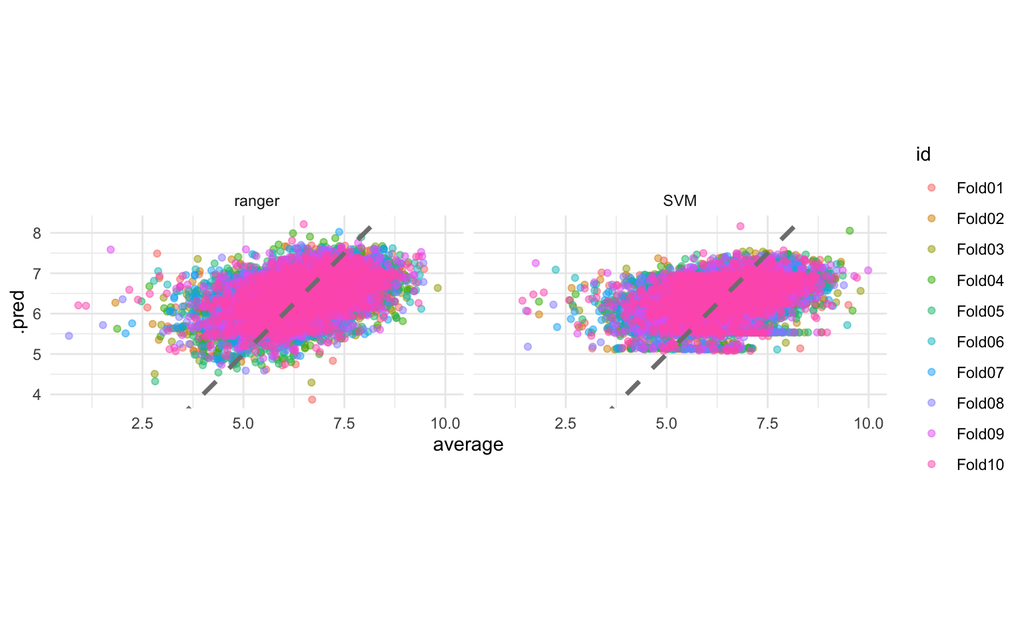

```r
bind_rows(
  collect_predictions(svm_rs) %>%
    mutate(mod = "SVM"),
  collect_predictions(ranger_rs) %>%
    mutate(mod = "ranger")
) %>%
  ggplot(aes(average, .pred, color = id)) +
  geom_jitter(width = 0.5, alpha = 0.5) +
  geom_abline(lty = 2, color = "gray50", size = 1.2) +
  facet_wrap(vars(mod)) +
  coord_fixed()
```

Lets go with the random forest for the final fit:

```r
final_fitted <- last_fit(rf_wf, board_split)
collect_metrics(final_fitted)
```

```
## # A tibble: 2 × 4
##   .metric .estimator .estimate .config
##   <chr>   <chr>          <dbl> <chr>
## 1 rmse    standard       0.833 Preprocessor1_Model1
## 2 rsq     standard       0.216 Preprocessor1_Model1
```

This fitted workflow object can now be used for prediction. Lets predict the rating for the 100th entry:

```r
final_wf <- extract_workflow(final_fitted)
predict(final_wf, board_test[100, ])
```

```
## # A tibble: 1 × 1
##   .pred
##   <dbl>
## 1  6.25
```